# R Notebook

### Loading Packages

```r
library(tidyverse)
library(multcomp)
library(tibble)
library(yarrr)
library(readr)
library(mosaic)
```

3.10 Practice problems

3.1. Cholesterol Analysis For the first practice problems, you will work with the cholesterol data set from the `multcomp` package that was used to generate the Tukey’s HSD results. To load the data set and learn more about the study, use the following code:

```r
cholesterol <- as_tibble(cholesterol)
help(cholesterol)
```

3.1.1. Graphically explore the differences in the changes in Cholesterol levels for the five levels using pirate-plots.

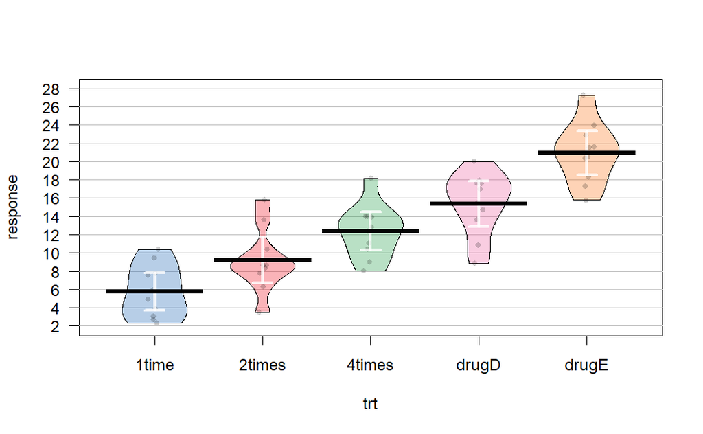

```r
pirateplot(response ~ trt, data = cholesterol, inf.method = "ci", inf.disp = "line")
```

3.1.2. Is the design balanced? Generate R output to support this assessment.

Answer: The data to be balanced. The QQ-plot suggests that the data follows as the data points lie roughly on the line indicating a the linear model. Furthermore, the density plot suggests that the data depicts a roughly normal distribution.

```r
favstats(response ~ trt, data = cholesterol)
```

| trt | min | Q1 | median | Q3 | max | mean | sd | n | missing |
| --- | --- | --- | --- | --- | --- | --- | --- | --- | --- |
| 1time | 2.3039 | 3.260975 | 5.41510 | 7.672825 | 10.3868 | 5.78197 | 2.878113 | 10 | 0 |
| 2times | 3.5054 | 7.913800 | 8.61465 | 10.106325 | 15.8258 | 9.22497 | 3.483054 | 10 | 0 |
| 4times | 8.0534 | 10.554875 | 12.60540 | 13.949850 | 18.1794 | 12.37478 | 2.923119 | 10 | 0 |
| drugD | 8.8194 | 13.873475 | 16.21975 | 17.621125 | 19.9793 | 15.36117 | 3.454636 | 10 | 0 |
| drugE | 15.7707 | 18.825625 | 21.01590 | 22.561875 | 27.2445 | 20.94752 | 3.345003 | 10 | 0 |

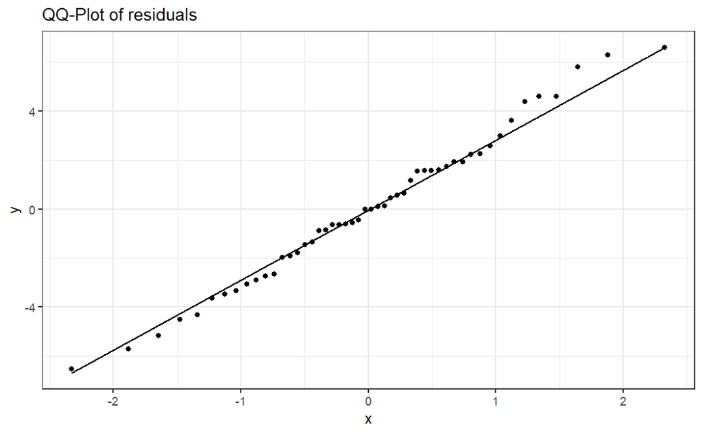

```r
ch_lm <- lm(response ~ trt, data = cholesterol)

cholesterol <- cholesterol %>%
  mutate(res = residuals(ch_lm))

cholesterol %>%
  ggplot(aes(sample = res)) +
  geom_qq() +
  stat_qq_line() +
  theme_bw() +
  labs(title = "QQ-Plot of residuals")
```

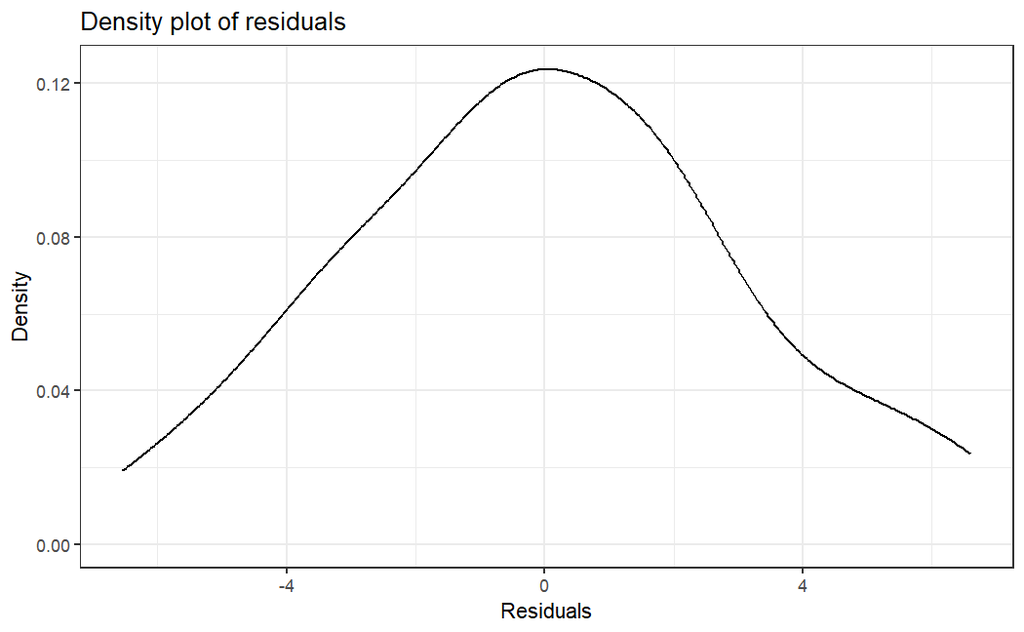

```r
cholesterol %>% ggplot(mapping = aes(x = res)) +
  geom_density() +
  labs(x = "Residuals",
       y = "Density",
       title = "Density plot of residuals") +
  theme_bw()
```

3.1.3. Complete all 6+ steps of the hypothesis test using the parametric F-test, reporting the ANOVA table and the distribution of the test statistic under the null. When you discuss the scope of inference, make sure you note that the treatment levels were randomly assigned to volunteers in the study.

$H_0$: $\mu_1$ = $\mu_2$ = $\mu_4$ = $\mu_D$ = $\mu_E$ $H_a$: Not all $\mu$ are equal

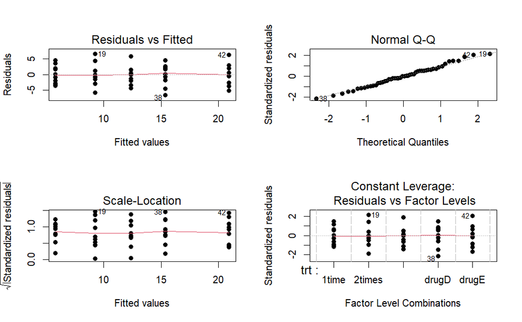

```r
par(mfrow = c(2,2))
plot(ch_lm, pch = 16)
```

Due to the lack of sufficient information, we can start by assuming that there was little interactions between the patients, and hence assume independence between different groups and that they are exclusive.

The anova is a parametric approach. The anova generates the following p-value and F-statistic values.

```r
anova(ch_lm)
```

```
Analysis of Variance Table

Response: response
          Df  Sum Sq Mean Sq F value    Pr(>F)
trt        4 1351.37  337.84  32.433 9.819e-13 ***
Residuals 45  468.75   10.42
---
Signif. codes:  0 ‘***’ 0.001 ‘**’ 0.01 ‘*’ 0.05 ‘.’ 0.1 ‘ ’ 1
```

Given tbe p-value, we can conclude that there is strong evidence against the null hypothesis that all treatments will yield the same results.

The various treatment groups for cholesterol patients exhibited a mean difference ranging from ~5 to ~22 in cholesterol reduction. However, due to the lack of additional information about the individuals included in this study, we are unable to establish a specific scope of inference.

3.1.4. Generate the permutation distribution and find the p-value. Compare the parametric p-value to the permutation test results.

The p-value of the parametric and permutation tests are very similar with both values being less than 0.0001.

```r
Tobs <- anova(lm(response ~ trt, data = cholesterol))[1,4]; Tobs
```

```
[1] 32.43283
```

```r
B <- 1000
cholesterol_d <- matrix(NA, nrow = B)

for (b in (1:B)){
  cholesterol_d[b] <- anova(lm(response ~ shuffle(trt), data = cholesterol))[1,4]
}

pdata(cholesterol_d, Tobs, lower.tail = F)[[1]]
```

```
[1] 0
```

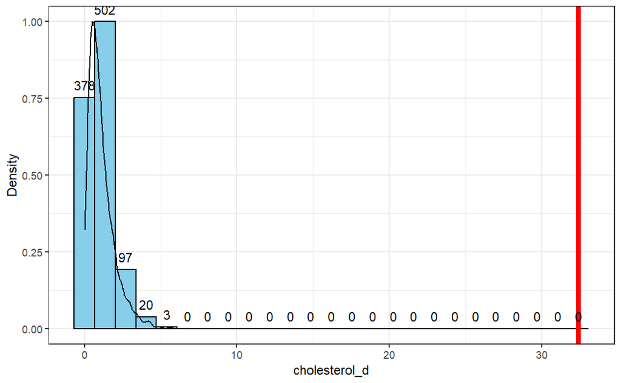

```r
tibble(cholesterol_d) %>%
  ggplot(aes(x = cholesterol_d)) +
  geom_histogram(aes(y = ..ncount..), bins = 25, col = 1, fill = "skyblue") +
  geom_density(aes(y = ..scaled..)) +
  theme_bw() +
  labs(y = "Density") +
  geom_vline(xintercept = Tobs, col = "red", lwd = 2) +
  stat_bin(aes(y = ..ncount.., label = ..count..), bins = 25, geom = "text", vjust = -0.75)
```

3.1.5. Perform Tukey’s HSD on the data set. Discuss the results – which pairs were detected as different and which were not? Bigger reductions in cholesterol are good, so are there any levels you would recommend or that might provide similar reductions?

```r
Tm2 <- glht(ch_lm, linfct = mcp(trt = "Tukey"))
confint(Tm2)
```

```
     Simultaneous Confidence Intervals

Multiple Comparisons of Means: Tukey Contrasts


Fit: lm(formula = response ~ trt, data = cholesterol)

Quantile = 2.8422
95% family-wise confidence level


Linear Hypotheses:
                     Estimate lwr     upr
2times - 1time == 0   3.4430  -0.6594  7.5454
4times - 1time == 0   6.5928   2.4904 10.6952
drugD - 1time == 0    9.5792   5.4768 13.6816
drugE - 1time == 0   15.1655  11.0632 19.2679
4times - 2times == 0  3.1498  -0.9526  7.2522
drugD - 2times == 0   6.1362   2.0338 10.2386
drugE - 2times == 0  11.7225   7.6202 15.8249
drugD - 4times == 0   2.9864  -1.1160  7.0888
drugE - 4times == 0   8.5727   4.4704 12.6751
drugE - drugD == 0    5.5863   1.4840  9.6887
```

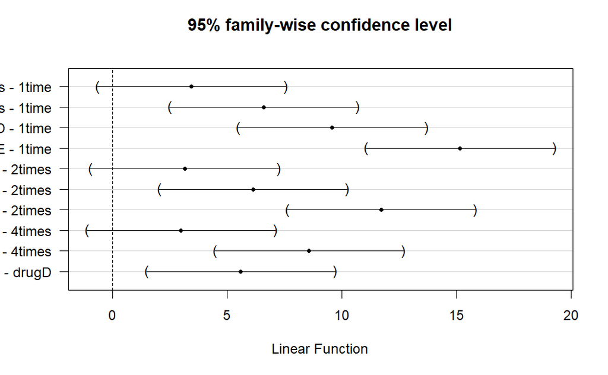

```r
plot(Tm2)
```

3.1.6. Find and interpret the CLD and compare that to your interpretation of results from 3.1.5. The Tukey plot suggests that drugE has the highest success rate. Thus, suggested drug would be drugE.

```r
confint(ch_lm)
```

```
                 2.5 %    97.5 %
(Intercept)  3.7263334  7.837607
trt2times    0.5358908  6.350109
trt4times    3.6857008  9.499919
trtdrugD     6.6720908 12.486309
trtdrugE    12.2584408 18.072659
```

3.2. Sting Location Analysis These data come from [Smith, 2014] where the author experimented on himself by daily stinging himself five times on randomly selected body locations over the course of months. You can read more about this fascinating (and cringe inducing) study at https://peerj.com/articles/338/. The following code gets the data prepared for analysis by removing the observations he took each day on how painful it was to sting himself on his forearm before and after the other three observations that were of interest each day of the study. This is done with a negation (using $“!”$ of the `%in%` which identifies rows related to the two daily forearm locations (`Forearm` and `Forearm1`) to leave all the rows in the data set for any levels of `Body_Location` that were not in these two levels. This is easier than trying to list all 24 other levels, then `Body_Location` variable is re-factored to clean out its unused levels, and finally the reorder function is used to order the levels based on the sample mean pain rating – and the results of these steps are stored in the `sd_fixedR` tibble.

```r
sd_fixed <- read_csv("http://www.math.montana.edu/courses/s217/documents/stingdata_fixed.csv")
sd_fixedR <- sd_fixed %>%
  filter(!(Body_Location %in% c("Forearm", "Forearm1"))) %>%
  mutate(Body_Location = factor(Body_Location),
         Body_Location = reorder(Body_Location, Rating, FUN = mean))
```

3.2.1. Graphically explore the differences in the pain ratings (`Rating`) across the different Body_Location levels using boxplots and pirate-plots. How are boxplots misleading for representing these data? Hint: look for discreteness in the responses.

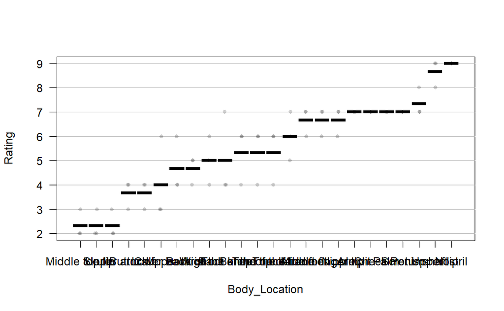

```r
pirateplot(Rating ~ Body_Location, data = sd_fixedR)
```

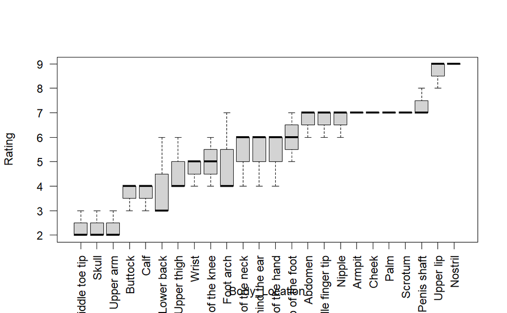

```r
boxplot(Rating ~ Body_Location, data = sd_fixedR, las = 2)
```

3.2.2. Is the design balanced? The residuals plot indicates roughly normal/symmetric distribution. The qq-plot on the other hand has points horizontally aligned at regular intervals gyet roughly lie on the line and indicate normal distribution.

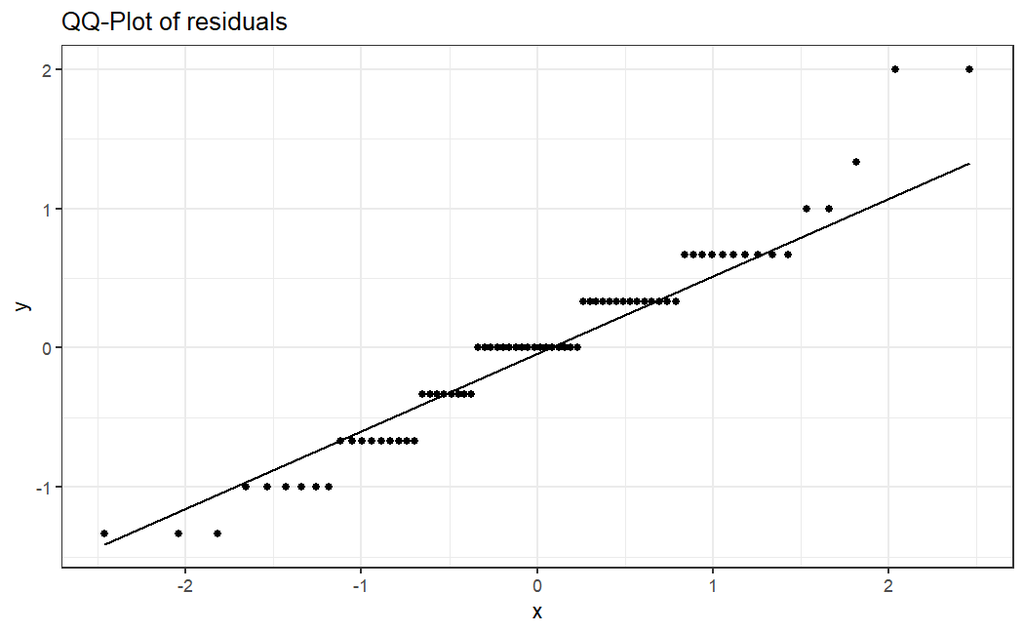

```r
lm1 <- lm(Rating ~ Body_Location, data = sd_fixedR)

sd_fixedR <- sd_fixedR %>%
  mutate(res = residuals(lm1)) #Adds residuals to cholesterol

sd_fixedR %>%
  ggplot(aes(sample = res)) +
  geom_qq() +
  stat_qq_line() +
  theme_bw() +
  labs(title = "QQ-Plot of residuals")
```

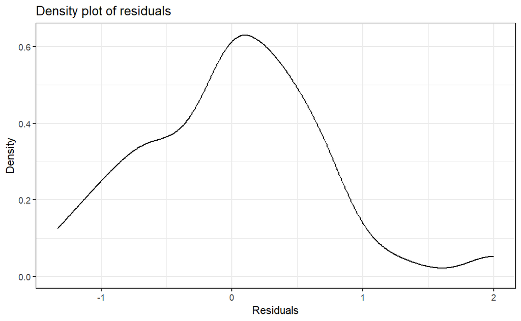

```r
sd_fixedR %>%
  ggplot(mapping = aes(x = res)) +
  geom_density() +
  labs(x = "Residuals",
       y = "Density",
       title = "Density plot of residuals") +
  theme_bw()
```

3.2.3. How does taking 3 measurements that are of interest each day lead to a violation of the independence assumption here?

Collecting 3 measurements of interest each day may violate the independence assumption since measurements within the same day could be influenced by common daily factors, compromising the randomness and independence required for accurate statistical analysis.

3.2.4. Complete all 6+ steps of the hypothesis test using the parametric F-test, reporting the ANOVA table and the distribution of the test statistic under the null. For the scope of inference use the information that the sting locations were randomly assigned but only one person (the researcher) participated in the study.

1. Hypotheses: $H_0$: $\mu$ (same for all body parts) $H_a$: Not all $\mu$ are equal
2. Plot the data and assess validity conditions:

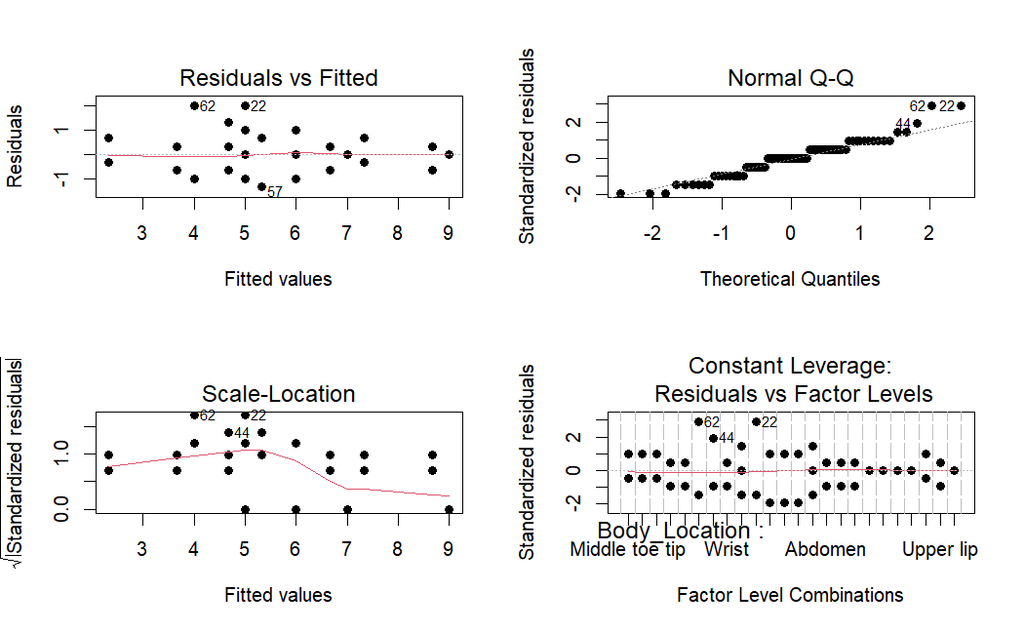

```r
par(mfrow = c(2,2))
plot(lm1, pch = 16)
```

The experiment aimed to investigate the impact of the sting location on the perceived pain intensity. It is hypothesized that repeated stinging by the individual would potentially elevate their pain tolerance, resulting in varying levels of pain for initial stings.

The graphical representations reveal differences in variability among the distinct groups. The discrepancies can be linked to the limited sample size, as each group comprised only three data points. In the residual vs fitted plot, the disparities in spreads are observed across different body parts. The Scale-Location plot further shows variability differences among the groups, indicating a deviation from the expected assumptions.

Examining the Q-Q plot, it is evident that the majority of data points align well with the reference line, with some deviations at the extreme values. Consequently, there is no apparent issue with normality in the dataset.

3.2.5. Generate the permutation distribution and find the p-value. Compare the parametric p-value to the permutation test results.

```r
Tobs1 <- anova(lm(Rating ~ Body_Location, data = sd_fixedR))[1,4]; Tobs1
```

```
[1] 14.72805
```

```r
B <- 1000
Tstar1 <- matrix(NA, nrow = B)
for (b in (1:B)){
  Tstar1[b] <- anova(lm(Rating ~ Body_Location, data = sd_fixedR))[1,4]
}

pdata(Tstar1, Tobs1, lower.tail = F)[[1]]
```

```
[1] 0
```

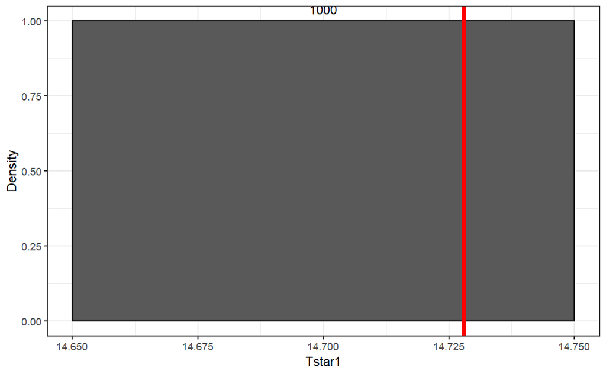

```r
tibble(Tstar1) %>%
  ggplot(aes(x = Tstar1)) +
  geom_histogram(aes(y = ..ncount..), bins = 25, col = 1) +
  geom_density(aes(y = ..scaled..)) +
  theme_bw() +
  labs(y = "Density") +
  geom_vline(xintercept = Tobs1, col = "red", lwd = 2) +
  stat_bin(aes(y = ..ncount.., label = ..count..), bins = 25, geom = "text", vjust = -0.75)
```

3.2.6. Generate an effects plot (use something like plot(allEffects(lm_model), rotx = 45) to rotate the x-axis text 45 degrees so you can read it!). Which of the locations did he find most painful on average?

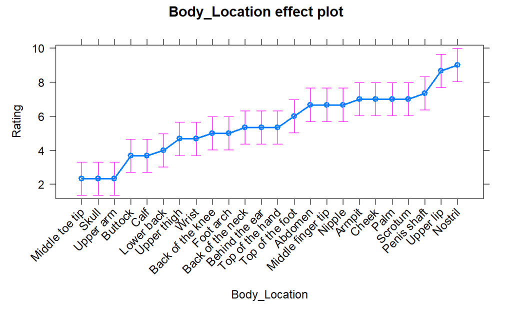

```r
plot(allEffects(lm1), rotx = 45)
```

The 3 locations that were found to be the most painful were the penis shaft, upper lip and nostril in order as seen in the figure above.

3.2.7. Generated our standard panel of diagnostic plots. In the QQ-Plot, you should see a stair-step pattern that presents a violation of the normality assumption that we have not see before. Look at your answer to 3.2.1 and try to explain why this pattern is present.

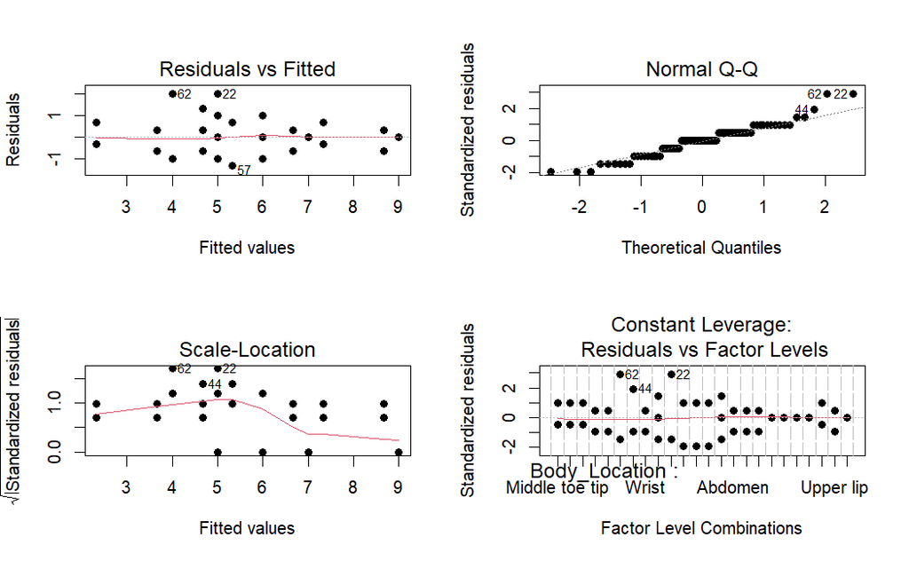

```r
par(mfrow = c(2,2))
plot(lm1, pch = 16)
```

The stair-step pattern distribution of points is due to integer values (pain ratings) being whole integers on a certain scale, thus causing the possibility of same rating for multiple body parts, or simply follows a discrete pattern of distribution rather than continuous.

3.2.8. Often we might consider Tukey’s pairwise comparisons given the initial result here. How many levels are there in Body_Location in the filtered data set? How many pairs would be compared if we tried Tukey’s – calculate this using the choose function?

```r
choose(24,2)
```

```
[1] 276
```

Tukey’s pairwise comparison would allow us 276 pairs to choose from.